# FinalreportAnneGro

## **Seasonal changes in pythoplankton and zooplankton in correlation to the Arctic sea ice retreat**

## Abstract

The arctic ocean is the world smallest ocean and have mostly been covered in ice. One of the more well-known consequences of climate change is the drastic change in sea ice concentration in this area. Changes in the arctic ice are not only amplifying the warming, but does also have a great influence on the arctic ecosystem. Considering the importance of algal life it is especially interesting to understand how it affects phytoplankton.The importance of phytoplankton can not be overlooked as it is the fondation of the aquatic food web and the largest source of transferring carbon dioxide between the atmosphere and ocean. The decrease in sea ice is linked to longer open-water phytoplankton habitat creating changes in their seasonal pattern. In this report, comparing three different areas in the Arctic, we use the second version of the Norwegian Earth System Modcel(NorESM2) to study the seasonal changes in phytoplankton and zooplankton in correlation to the sea ice retreat.

## Introduction

Phtoplankton are small organisms living in the sea. Just like terrestrial plants they have photosynthesis and are very dependent on access to sunlight to live. Hence, they are mostly located in the upper part off the ocean, where the sunlight penetrates the water., (Lindsey, Scott 2010) In addition they are also dependent on carbon dioxide and nutrients.

The importance of phytoplankton can not be overlooked. They are the foundation of the aquatic food-web. In a balanced ecosystem they are the main source of food for a wide range of sea creatures like shrimps and jellyfish, known as zooplankton. Zooplankton are than again the main source of food for small fish and so on. In addition phytoplankton is also the main transfer of CO2 between the ocean and the atmosphere. Each year 10 gigaton of Co2 are transferred in between the two. Hence, a changes in population of phytoplankton can have great consequences. Thus, it is very important to understand how the population is affected by climate change, and how it will affect climate change.

The seasonal variations of phytoplankton varies from area to area. In high latitudes blooms peak in the spring and summer, as sunlight increases and the vertical mixing caused by winter storms subsides.(Lindsey, Scott, 2010). The blooming last for a few weeks before it decreases as the phytoplankton uses up the nutrients that have built up over the winter and the production decreases til the next bloom the next spring. The changes in the arctic atmosphere and ocean are drastically affecting the dynamics of phytoplankon and their seasonal pattern. As a result of global warming we have seen a rapid decrease in the arctic sea ice the last decades.The decreased in sea ice have led to feedback that further amplify the arctic warming indicating that we will see an even more rapid decrease in the future.As the sea ice decreases more of the ocean surface is exposed to sunlight. Thus, more sunlight are penetrating the ocean surface and contributing to growth in phytoplankton. Global warming does also contribute to an increase in freshwater input from sea ice, glacier, river inflow and increased net precipitation. This will likely reduce the vulnerability of the vertical mixing of carbon and nutrients making more nutrients available for the phytoplankton. However, a lot of nutrients are building up under the sea ice during the winter months and are a necessary part of the seasonal pattern of phytoplankton in the area. (Ardyna, M., 2020)

In this rapport we are using the second version Norwegian Earth System Model(NorESM2) to look at the seasonal cycles of phytoplankton and zooplankton in three different areas of the Arctic experiencing sea ice decrease in different speed. As a consequence of global warming and the arctic sea ice retreat it is expected to see a shift in the seasonal patterns of the phytoplankton. By stuiding the three areas we can compare and see if the changes are bigger in areas with a more rapid decrease than in areas where we don't see as much change.

## Method

Importing phyton packages:

```python
import xarray as xr
xr.set_options(display_style='html')
import intake
import cftime
import numpy as np
import matplotlib.pyplot as plt
import cartopy.crs as ccrs
import s3fs
%matplotlib inline

import xesmf as xe

#Importing functions from function file:
from myfuctions import *
%reload_ext autoreload
%autoreload 2

#Ignoring phyton warnings when plotting
import warnings
warnings.filterwarnings('ignore')
```

```python
modelname = 'NorESM2-LM'
```

```python
#Open area and data
areacello = getareacello(modelname)
```

```
--> The keys in the returned dictionary of datasets are constructed as follows:
	'activity_id.institution_id.source_id.experiment_id.table_id.grid_label'
```

100.00% [1/1 00:00<00:00]

**Data:** To look at the seasonal pattern of phytoplankton NorESM2-LM have been used. The model is based on the second version of the Community Earth System Model(CESM2).The ocean Model Intercomparison Project(OMIP) was used. The experiment provides a protocol for global ocean/sea-ice models forced by prescribed atmospheric forcing and includes a physical and a biogeochemistry component. (Seland,Ø et al, 2020) The simulation is from 1948-2008, and I have mainly used the 20 first and 20 last years of this period.To understand the affect of climate change on phytoplanktons and zooplankton seasonal patterns the following variables where studied: sea ice concentration(sinconc), net shortwave radiation on sea surface(rsntds), Chlorofyll concentration(chlos), and carbon concentration (zoocos). The ensemble memver I used was r1i1plfl.

```python
# Reding the dataset and choosing variables:
varlist = ['rsntds', 'chlos', 'zoocos']
ds_ocn=xr.merge([read_omip_bucketdata(modelname, realm='Omon', var=var ) for var in varlist])
ds_ice = read_omip_bucketdata(modelname, realm='SImon', var='siconc')
varlist = ['siconc'] + varlist
```

```
rsntds
chlos
zoocos
siconc
```

Started to choosing my areas by plotting an anomaly map for each season. Compeared the 20 first year of the model simulation with the 20 last years and plotted the whole Artic to see where the retreate where more significant.

```python
#Finding the seasonal mean of the sea ice consentration of the two periodes
var = 'siconc'
dsStart=make_seasonmean(ds_ice[var].sel(time=slice('1948-01-01','1967-12-31')))  #1948-1968
dsEnd=make_seasonmean(ds_ice[var].sel(time=slice('1988-01-01', '2007-12-31')))   #1988-2008
```

```python
#Gridding the data
ds_out = xe.util.grid_global(1, 1)
regridder = xe.Regridder(dsStart.to_dataset(name = var), ds_out, 'bilinear')
```

```python
dr_out = regridder(dsEnd) - regridder(dsStart)
```

```python
dr_out = xr.where(dr_out==0,np.nan,dr_out)
```

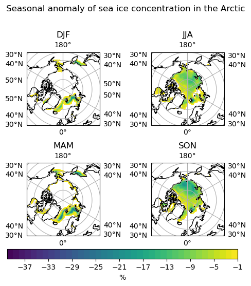

```python
#Plotting an sea-ice consentration anomaly map for each season.

f, axs = plt.subplots(2,2 ,subplot_kw=dict(projection=ccrs.Orthographic(0,90)))
f.suptitle('Seasonal anomaly of sea ice concentration in the Arctic', y=1.1, x=0.4)
axs=axs.flatten()
levels=np.arange(-40, -.1,1)
i=0

for season in dr_out.season.values:
    cf=plotmap(axs[i], dr_out, season, levels)
    i= i+1

cax = f.add_axes([.04, .07, .7, .04])
plt.colorbar(cf, cax=cax, orientation='horizontal', label='%')
plt.subplots_adjust(left=0.1, bottom=.15, top= .92, right=.7, wspace=0.7, hspace=.4)
```

**Figure 1:** *A plotted map of the anomalies of sea ice concentration for each season in the Arctic. The plot shows a significant decrease in sea ice concentration in the Baren sea from 1948-1968 to 1988-2008.*

**Choosing my study areas:**

When choosing my study areas I wanted to look at three different areas where we see different responses to sea ice in the Arctic. Figure 1 shows an anomaly in sea ice concentration between 1948-1968 to 1988-2008 for each season. As mentioned phytoplankton blooms in spring and summer, thus I wanted to look at an area where we can see a large decrease in the spring months and one where we could see a large decrease in the summer months. I also wanted to look at an area where there was little - to no decrease in sea ice.

Figure 1 shows a significant decrease in spring sea ice in the Barents see. The Barents sea is located between the northern coast of Norway and Svalbard. Nutrients are usually abundant and well mixed in the Barnets sea in the spring causing optimal conditions for phytoplankton to grow in. With accessible sunlight, this is a great area for phytoplankton to bloom during these months. (Vernet, 2009 )

Laptev sea is located between the Siberian coast in the south, the Taymyr Peninsula in the west, and the New Siberian Islands in the east. The anomaly in figure 1 shows a great decrease in sea ice during summer and autumn. Laptev sea is usually covered in ice during the winter months and is usually one of the first places the winter sea ice reappears after the summer season. However, in the last decades, winter sea ice has started to appear later than before.The sea does also have a lot of freshwater input from rivers contributing to vertical mixing and the upbringing of nutrients to the ocean surface. Hence, as long as there is accessible sunlight Laptev sea is also a good place for phytoplankton bloom. (Peters et al,2004)

The last location I'm looking at is the Kara sea. Kara sea is located between the Barnets sea and Laptev sea. However, in this area we don't really see a decrease in sea ice and it would be interesting to look at the changes in seasonal patterns in this area in comparison to the areas that actually have experienced a great decrease in sea ice. (Flint et al. 2018)

**Latitudes and longitudes of the Barnets, Lapetv and Kara sea:**

```python
#Laptev sea latitude and longitude:
Llat_min=70
Llat_max=80

Llon_max=160
Llon_min=120

#Kara sea latitude and longitude:
BBlat_min=74
BBlat_max=81

BBlon_max=97
BBlon_min=58

#Baren sea latidtude and longitude:
lat_min = 65.9
lat_max= 81.9

lon_min=16.6
lon_max=68.6

#No ice lats
maxla=66.0
minla=55.2

maxlo=10
minlo=-13
coordinates = [[Llat_min, Llat_max, Llon_min, Llon_max], [BBlat_min, BBlat_max, BBlon_min, BBlon_max], [lat_min, lat_max, lon_min, lon_max]]
```

**Plotting the locations on a map:**

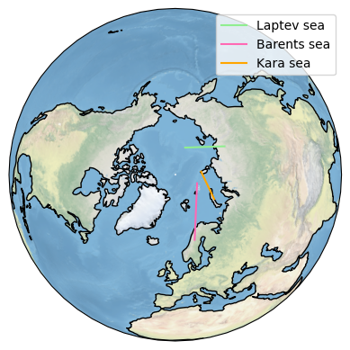

```python
#Plotting the locations to show on the map
ax = plt.axes(projection=ccrs.Orthographic(0,90))
ax.stock_img()
ax.coastlines()


plt.plot([Llon_max, Llon_min],[Llat_max, Llat_min],  color='lightgreen', transform=ccrs.Geodetic(), label='Laptev sea ')
plt.plot([lon_max, lon_min],[lat_max, lat_min],  color='hotpink', transform=ccrs.Geodetic(), label='Barents sea')
plt.plot([BBlon_max, BBlon_min],[BBlat_max, BBlat_min],  color='orange', transform=ccrs.Geodetic(),label='Kara sea')
plt.legend()
```

**Figure 2:** *The plot is showing the locations of my study areas*

After choosing my locations I calculated the monthly means in the NorESM2 for every variable in all three study areas. I used this to look at the changes in each variable. I also plotted the anomalies for all three areas to see if it was any similar pattern in the changes of the variables in the different areas.

## Results

[figure not shown]

```python
fig, axs = plt.subplots(2, 2)        #Creating subplot

#Creating titles and colors for all plots
titles = ["Sea ice concentration", "Net downward solar radiation", "Chlorophyll concentration", "Zooplankton carbon concentration"]
colors=['palevioletred', 'pink', 'darkgreen', 'lightgreen', 'yellow', 'orange']

gr = fig.add_gridspec(ncols=2, nrows=2)
axs = axs.flatten()
fig.suptitle('Changes in seasonal cycle in Laptev sea' )

i = 0

#Plotting the seasonal changes in all variables in Barnents sea
for var, title in zip(varlist, titles):
    plot_variables(axs, var, title, ds_ice, ds_ocn, areacello, coordinates[2], i, colors[:2])
    i += 1

plt.subplots_adjust(left=0.05, bottom=.15, top=.9, right=.99, wspace=.3, hspace=.5)
plt.savefig('figures/sesav.png')
```

**Figure 3:** *The figure shows 4 plots for seasonal variances in sea ice concentration(siconc), net downward shortwave radiation(rsntds), chlorophyll concentration(chlos), and zooplankton concentration (zoocos) in the Barents sea.*

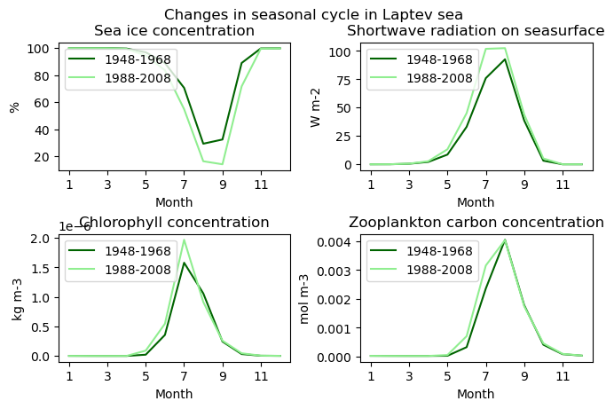

```python
fig, axs = plt.subplots(2, 2)     #Creating subplots


gr = fig.add_gridspec(ncols=2, nrows=2)
axs = axs.flatten()
fig.suptitle('Changes in seasonal cycle in Laptev sea' )

i = 0

#Plotting seasonal changes for all variables in Laptev sea
for var, title in zip(varlist, titles):
    plot_variables(axs, var, title, ds_ice, ds_ocn, areacello, coordinates[0], i, colors[2:])
    i += 1

plt.subplots_adjust(left=0.05, bottom=.15, top=.9, right=.99, wspace=.3, hspace=.5)
plt.savefig('figures/sesav.png')
```

**Figure 4:** *The figure shows 4 plots for seasonal variances in sea ice concentration(siconc), net downward shortwave radiation(rstdns) , chlorophyll concentration(chlos), and zooplankton concentration(zoocos) at the sea surface in the Laptev sea.*

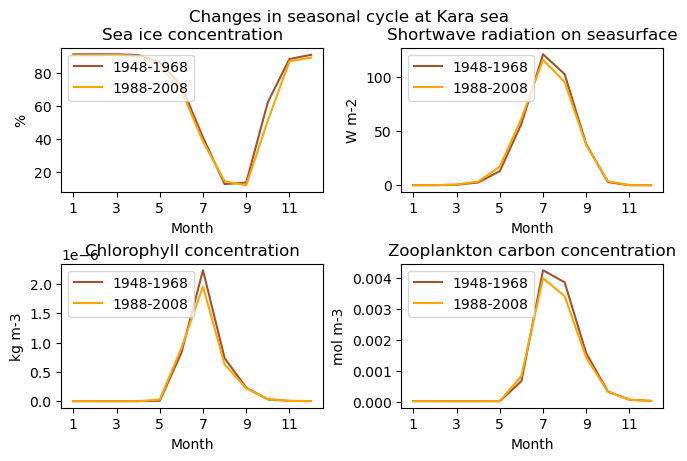

```python
fig, axs = plt.subplots(2, 2)                       #Creating subplots

gr = fig.add_gridspec(ncols=2, nrows=2)
axs = axs.flatten()
fig.suptitle('Changes in seasonal cycle at Kara sea' )

i = 0

#Plotting the seasonal changes in all variables in Kara sea
for var, title in zip(varlist, titles):
    plot_variables(axs, var, title, ds_ice, ds_ocn, areacello, coordinates[1], i, colors[4:])
    i += 1

plt.subplots_adjust(left=0.05, bottom=.15, top=.9, right=.99, wspace=.3, hspace=.5)
plt.savefig('figures/sesav.png')
```

**Figure 5:** *The figure shows 4 plots for seasonal variances in sea ice concentration(siconc), net downward shortwave radiation(rsndts), chlorophyll concentration(chlos), and zooplankton concentration(zoocos) at the sea surface in Kara sea.*

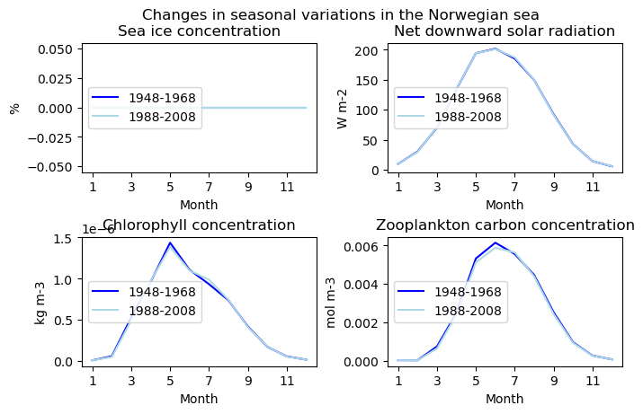

```python
fig, axs = plt.subplots(2, 2)                                                       #Creating subplots
axs = axs.flatten()
fig.suptitle('Changes in seasonal variations in the Norwegian sea' )                #Setting title for subplot

i = 0


for var, title in zip(varlist, titles):
    if var == 'siconc':
        ds = ds_ice
    else:
        ds = ds_ocn

    dsStart=make_monthlymean(ds[var].sel(time=slice('1948-01-01','1967-12-31'))).to_dataset(name = var)   #Monthlymean of 1948-1968
    dsEnd=make_monthlymean(ds[var].sel(time=slice('1988-01-01', '2007-12-31'))).to_dataset(name = var)    #Monthymean of  1988-2008
    dsStartBS = regional_avg(dsStart, areacello, var,  minla, maxla, minlo, maxlo)                        #Choosing region 1948-1968
    dsEndBS = regional_avg(dsEnd, areacello, var,  minla, maxla, minlo, maxlo)                            #Choosing reging 1988-2008

    ax = axs[i]

    ax.plot(dsStartBS.month, dsStartBS, color='blue', label='1948-1968')
    ax.plot(dsEndBS.month, dsEndBS, color='lightblue', label='1988-2008' )

    ax.set_ylabel(ds[var].units)
    ax.set_xlabel('Month')
    ax.set_xticks(np.arange(1,13,2))

    ax.legend(loc='center left')
    ax.set_title(title)

    i = i+1


plt.subplots_adjust(left=0.05, bottom=.15, top=.9, right=.99, wspace=.3, hspace=.5)
plt.savefig('figures/sesav.png')
```

**Figure 6**: *The figure is showing the seasonal variations for the Norwegian sea. In the Norwegian sea there is no sea ice.*

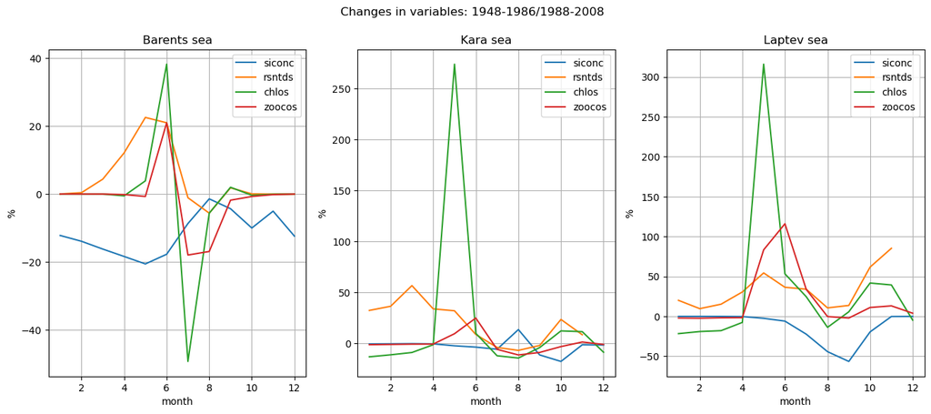

```python
plt.figure(figsize=(16,6))
plt.suptitle('Changes in variables: 1948-1986/1988-2008')

#Plotting anamolies for Baren sea
plt.subplot(1,3,1)
for var in varlist:
    if var == 'siconc':
        ds = ds_ice
    else:
        ds = ds_ocn
    dsStart=make_monthlymean(ds[var].sel(time=slice('1948-01-01','1967-12-31'))).to_dataset(name = var)
    dsEnd=make_monthlymean(ds[var].sel(time=slice('1988-01-01', '2007-12-31'))).to_dataset(name = var)
    dsStartBS = regional_avg(dsStart, areacello, var,  lat_min, lat_max, lon_min, lon_max)
    dsEndBS = regional_avg(dsEnd, areacello, var,  lat_min, lat_max, lon_min, lon_max)

    plt.plot(dsEndBS.month, ((dsEndBS-dsStartBS)/dsStartBS.mean())*100, label=var)
    plt.title('Barents sea')
    plt.xlabel('month')
    plt.ylabel('%')
    plt.legend()
plt.grid()

#Plotting anamolies for the Kara sea
plt.subplot(1,3,2)
for var in varlist:
    if var == 'siconc':
        ds = ds_ice
    else:
        ds = ds_ocn

    dsStart=make_monthlymean(ds[var].sel(time=slice('1948-01-01','1967-12-31'))).to_dataset(name = var)
    dsEnd=make_monthlymean(ds[var].sel(time=slice('1988-01-01', '2007-12-31'))).to_dataset(name = var)
    dsStartBB = regional_avg(dsStart, areacello, var,  BBlat_min, BBlat_max, BBlon_min, BBlon_max)
    dsEndBB = regional_avg(dsEnd, areacello, var,  BBlat_min, BBlat_max, BBlon_min, BBlon_max)

    plt.plot(dsEndBB.month, ((dsEndBB-dsStartBB)/dsStartBB)*100, label=var)
    plt.title('Kara sea')
    plt.ylabel('%')
    plt.xlabel('month')
    plt.legend()
plt.grid()


#Plotting anamolies for the Laptev sea
plt.subplot(1,3,3)
for var, title in zip(varlist, titles):
    if var == 'siconc':
        ds = ds_ice
    else:
        ds = ds_ocn
    dsStart=make_monthlymean(ds[var].sel(time=slice('1948-01-01','1967-12-31'))).to_dataset(name = var)
    dsEnd=make_monthlymean(ds[var].sel(time=slice('1988-01-01', '2007-12-31'))).to_dataset(name = var)
    dsStartC = regional_avg(dsStart, areacello, var,  Llat_min, Llat_max, Llon_min, Llon_max)
    dsEndC = regional_avg(dsEnd, areacello, var,  Llat_min, Llat_max, Llon_min, Llon_max)

    plt.plot(dsEndC.month, ((dsEndC-dsStartC)/dsStartC)*100, label=var)
    plt.title('Laptev sea')
    plt.ylabel('%')
    plt.xlabel('month')
    plt.legend()
plt.grid()
```

The plots show a significant change in sea ice concentration, net primary production, and zooplankton.

*Figure 3* shows the seasonal variations of the variables in question in the Barents sea. As expected we can see that there has been a decrease in sea ice and an increase in net downward solar radiation on the sea surface. We can also see a shift in the start production of chlorophyll that indicates the concentration of phytoplankton. We can say the same about zooplankton which also is experiencing an earlier increase.

*Figure 5* shows the seasonal variations of the variables in the Kara sea. Of all the areas this is the one with the smallest change in sea ice concentration the concentration is even increasing in the late summer which we also can see in the net downwards shortwave radiation. The plots also show a decrease in both phytoplankton and zooplankton and there is no change in the period of the blooming of phytoplankton.

*Figure 6* shows an area without sea ice. This plot is only used to show that we don't have the same changes in phytoplankton in areas where we don't have sea ice.

## Discussion and outlook

NorESM2 shows changes in seasonal patterns for all areas. However, the changes in the seasonal cycle of phytoplankton Can not only be explained by a longer open-water period. Nutrient availability and sea surface temperature are also important factors. We also have to take into consideration that different types of phytoplankton react differently to the sea ice retreat and all species are not represented in the model. Thus , there would be very useful to compare the model to other models and observations to validate the results.

*Figure 6* shows that we do not see any significant changes in the seasonal pattern of phytoplankton and zooplankton in an ice free area.

We can see a significant shift in both phytoplankton and zooplankton in Laptev sea. As figure shows there has been a huge decrease in sea ice and an increase in net shortwave downward radiation on the sea surface, leading to more accessible sunlight and contributing to the bloom in the phytoplankton. In this area compared to the Barents sea, we can both see a shift and an increase in population. As mentioned Laptev has a lot of freshwater input contributing to great vertical mixing and accessible nutrients for the phytoplankton. This gives an idea that the growth of pythoplankton in the area might mainly have been limited by the access to sunlight. In this area, there is also a zooplankton increase and shift that looks very related to the pythoplankton.

Comparing the results from Laptev and Barent sea we can see more significant changes in the seasonal changes in Laptev than in Barents sea even though both areas have experienced a significant decrease. However, the bloom in phytoplankton was already very early compared to Laptev. Since, the bloomingseason already started earlier in the Barents sea there is no significant change in the start of the blooming season. However, the peak is earlier. While Laptev have mostly been fully covered in ice, so just a litle change in the sea ice concentration have created an earlier bloom in the phytoplankton.

In Kara sea there is a decrease in phytoplankton and zooplankton. This makes sence since when there are less phytoplankton there will also be less zooplankton. Since there are litle to no change in sea ice concentration in the area the the decrese is likley not related to the sea ice. However, it can be caused by a change in available nutriens or other variables.

The results show that there is a greater shift in seasonal changes in phytoplankton and zooplankton in the areas with a significant decrease in sea ice. However, we can not conclude that it is the only reason for the changes, considering the growth of phytoplankton also is dependent on other variables. The results show that there is a correlation between seasonal changes in phytoplankton and zooplankton.The fact that we can see a more significant shift at the start of the blooming season in areas with a more significant decrease in sea ice may indicate that there is a great correlation between the two variables. However, there are still other factors to take into consideration when discussing primary production. There has only one model has been used in this study, and observations and other models are needed to validate the results.

## Acknowledgments

Thanks to Michael and Paul for organizating a great cours. Thanks to the Plankton group for helping me out whenever I needed and thanks to Ada for helping me so much with the code.

## Refrences:

Ardyna, M., Arrigo, K.R. Phytoplankton dynamics in a changing Arctic Ocean. Nat. Clim. Chang. 10, 892–903 (2020). https://doi.org/10.1038/s41558-020-0905-y

Lindsey, R., Scott, M., 2010, Phytoplankton,Nasa earth observatory, https://earthobservatory.nasa.gov/features/Phytoplankton

Peters, J.,Tuschling, K.,Brandt, A. 2004 ,Zooplankton in the arctic Laptev Sea—feeding ecology as indicated by fatty acid composition, Journal of Plankton Research, Volume 26, Issue 2, February 2004, Pages 227–234, https://doi.org/10.1093/plankt/fbh017

Seland, Øyvind; Bentsen, Mats; Oliviè, Dirk Jan Leo; Toniazzo, Thomas; Gjermundsen, Ada; Graff, Lise Seland; Debernard, Jens Boldingh; Gupta, Alok Kumar; He, Yan-Chun; Kirkevåg, Alf; Schwinger, Jörg; Tjiputra, Jerry; Aas, Kjetil Schanke; Bethke, Ingo; Fan, Yuanchao; Griesfeller, Jan; Grini, Alf; Guo, Chuncheng; Ilicak, Mehmet; Karset, Inger Helene H.; Landgren, Oskar Andreas; Liakka, Johan; Moseid, Kine Onsum; Nummelin, Aleksi; Spensberger, Clemens; Tang, Hui; Zhang, Zhongshi; Heinze, Christoph; Iversen, Trond; Schulz, Michael., 2020, Overview of the Norwegian Earth System Model (NorESM2) and key climate response of CMIP6 DECK, historical, and scenario simulations, https://doi.org/10.5194/gmd-13-6165-2020,

Sukhanova, I. & Flint, M. & Sergeeva, Valentina & Kremenetskiy, V.. (2011). Phytoplankton of the South-Western Part of the Kara Sea. Oceanology. 51. 10.1134/S000143701106018X.

Vernet, Maria.,2009, Phytoplankton dynamics in the Barents Sea estimated from chlorophyll budget models Phytoplankton dynamics in the Barents Sea estimated from chlorophyll budget models, Vol. 10 No. 1: Special issue: Proceedings of the Pro Mare Symposium on Polar Marine Ecology. Part 1 /, https://doi.org/10.3402/polar.v10i1.6733